# Data Exploration

Gaston Grant

2026-10-07

```r
files <- list.files(
  "Text Files",
  pattern = "\\.txt$",
  full.names = TRUE
)

texts <- tibble::tibble(
  document = basename(files),
  text = purrr::map_chr(files, readr::read_file)
)
```

```r
texts$text <- stringr::str_replace_all(texts$text, "ſ", "s")
```

```r
library(tibble)
library(dplyr)
```

```r
library(readr)
library(ggplot2)
library(quanteda)
library(quanteda.textstats)

corp <- corpus(
  texts,
  text_field = "text",
  docid_field = "document"
)

corp
```

```
## Corpus consisting of 23 documents.
## A06785.txt :
## "STrong imagination, nourished by opinion, may cause most men..."
##
## A06786.txt :
## "WHen Almighty God had created man, good and a sociable creat..."
##
## A06788.txt :
## "A SENTENCE alleged without application to some purpose, is t..."
##
## A06789.txt :
## "NATURAL Mother wit, did teach man, before Arts or Sciences w..."
##
## A06790.txt :
## "APRIL having with his sweet showers moistened the drought of..."
##
## A06791.txt :
## "PLato the Philosopher perceiving that equality would be the ..."
##
## [ reached max_ndoc ... 17 more documents ]
```

```r
toks <- tokens(
  corp,
  remove_punct = TRUE,
  remove_numbers = TRUE,
  remove_symbols = TRUE
)

toks <- tokens_tolower(toks)

custom_stop <- c(
  "vnto", "haue", "doo", "hath", "bee", "ye", "thee",
  "hee", "shall", "hast", "doe", "beene", "thereof", "thus"
)

toks <- tokens_remove(
  toks,
  pattern = c(stopwords("en"), custom_stop)
)

toks
```

```
## Tokens consisting of 23 documents.
## A06785.txt :
##  [1] "strong"      "imagination" "nourished"   "opinion"     "may"
##  [6] "cause"       "men"         "suppose"     "edward"      "misselden"
## [11] "sallust"     "s"
## [ ... and 17,336 more ]
##
## A06786.txt :
##  [1] "almighty"     "god"          "created"      "man"          "good"
##  [6] "sociable"     "creature"     "well"         "live"         "alone"
## [11] "creatures"    "sufficiently"
## [ ... and 110,273 more ]
##
## A06788.txt :
##  [1] "sentence"    "alleged"     "without"     "application" "purpose"
##  [6] "handle"      "matter"      "without"     "conclusion"  "attribute"
## [11] "unto"        "man"
## [ ... and 13,720 more ]
##
## A06789.txt :
##  [1] "natural"   "mother"    "wit"       "teach"     "man"       "arts"
##  [7] "sciences"  "invented"  "things"    "humane"    "actions"   "beginning"
## [ ... and 11,433 more ]
##
## A06790.txt :
##  [1] "april"       "sweet"       "showers"     "moistened"   "drought"
##  [6] "march"       "bathing"     "every"       "vein"        "roots"
## [11] "trees"       "engendering"
## [ ... and 5,528 more ]
##
## A06791.txt :
##  [1] "plato"       "philosopher" "perceiving"  "equality"    "cause"
##  [6] "every"       "man"         "enough"      "opinion"     "willed"
## [11] "things"      "common"
## [ ... and 8,618 more ]
##
## [ reached max_ndoc ... 17 more documents ]
```

## Data cleaning choices

I lowercased words so capitalization would not split their counts. Following the Week 04 tutorial, I removed punctuation so forms such as “commerce.” and “commerce!” would count together. I removed numbers and symbols to reduce interference from random numbers such as page count, and since our analysis is focusing on vocabulary, numbers aren’t as useful to us. I removed standard English stopwords and the tutorial’s historical stopwords to focus the comparison on content vocabulary rather than common grammatical words and to shorten the corpus in overall length.

## Approach 1 - TF-IDF

```r
dfm_mat <- dfm(toks)

dfm_mat
```

```
## Document-feature matrix of: 23 documents, 24,226 features (88.10% sparse) and 0
## docvars.
##             features
## docs         strong imagination nourished opinion may cause men suppose edward
##   A06785.txt      3           3         1      13  84    29  33       5      7
##   A06786.txt      9           1         0      49 798   254 287      24     36
##   A06788.txt      0           1         0      11  73    50  45       5      6
##   A06789.txt      0           0         0       4  80    81  23       3      3
##   A06790.txt      2           4         0       1  11    13  38       0      0
##   A06791.txt      1           0         0       3  35    36  21       3      5
##             features
## docs         misselden
##   A06785.txt        36
##   A06786.txt         0
##   A06788.txt         0
##   A06789.txt         0
##   A06790.txt         0
##   A06791.txt         0
## [ reached max_ndoc ... 17 more documents, reached max_nfeat ... 24,216 more
## features ]
```

```r
topfeatures(dfm_mat, 25)
```

```
##        upon       money       trade       great         may         one
##        4079        3204        3198        3162        3046        2961
##        much       price        part        said commodities        time
##        2205        2091        2059        2016        1967        1862
##        made         can        must     country    exchange       every
##        1841        1839        1705        1665        1640        1618
##        many      silver         two        make       value   merchants
##        1517        1470        1442        1413        1384        1357
##   therefore
##        1354
```

```r
dfm_tfidf <- dfm_tfidf(dfm_mat)

dfm_tfidf
```

```
## Document-feature matrix of: 23 documents, 24,226 features (88.10% sparse) and 0
## docvars.
##             features
## docs            strong imagination nourished   opinion may     cause men
##   A06785.txt 0.5569097   1.3759135  1.361728 1.3839193   0 0.5598495   0
##   A06786.txt 1.6707292   0.4586378  0        5.2163112   0 4.9035094   0
##   A06788.txt 0           0.4586378  0        1.1710086   0 0.9652578   0
##   A06789.txt 0           0          0        0.4258213   0 1.5637176   0
##   A06790.txt 0.3712732   1.8345514  0        0.1064553   0 0.2509670   0
##   A06791.txt 0.1856366   0          0        0.3193660   0 0.6949856   0
##             features
## docs           suppose    edward misselden
##   A06785.txt 0.4148712  2.852397   49.0222
##   A06786.txt 1.9913816 14.669472    0
##   A06788.txt 0.4148712  2.444912    0
##   A06789.txt 0.2489227  1.222456    0
##   A06790.txt 0          0           0
##   A06791.txt 0.2489227  2.037427    0
## [ reached max_ndoc ... 17 more documents, reached max_nfeat ... 24,216 more
## features ]
```

```r
tfidf_mat <- as.matrix(dfm_tfidf)

tfidf_top_tbl <- bind_rows(
  lapply(rownames(tfidf_mat), function(doc) {
    top_terms <- sort(tfidf_mat[doc, ], decreasing = TRUE)[1:15]

    tibble(
      document = doc,
      term = names(top_terms),
      tfidf = unname(top_terms)
    )
  })
)
```

```r
tfidf_top_tbl %>%
  group_by(document) %>%
  summarise(
    terms = paste(term, collapse = ", "),
    .groups = "drop"
  ) %>%
  knitr::kable(caption = "Distinctive Words by Document")
```

Distinctive Words by Document

| document | terms |
| --- | --- |
| A06785.txt | moneys, misselden, starlin, p, exchange, circle, realm, doller, undervaluation, royals, stivers, overbalancing, d, commodities, s |
| A06786.txt | ll, hundreth, ounces, weight, carrats, moneys, ss, factor, assurors, grains, antuerp, silver, unto, ducats, pieces |
| A06788.txt | m, sols, silver, livers, realm, dearth, commodities, gold, bodine, price, moneys, velvet, shillings, unto, malestroit |
| A06789.txt | moneys, starlin, monies, exchange, realm, commodities, shillings, doller, th, enhancing, price, stivers, pence, whereby, albeit |
| A06790.txt | monster, dragon, maketh, moon, unto, tail, ass, sweet, causeth, leaguors, smell, feeding, visions, hell, daughter |
| A06791.txt | realm, moneys, commodities, exchange, fineness, price, shillings, silver, exchangers, albeit, hundredth, bank, weight, unto, ducats |
| A07594__Circle_of_Commerce.txt | malynes, kingdome, mony, ballance, forraine, vpon, owne, lesse, vse, forme, himselfe, gaine, custome, sayd, yeare |
| A07886.txt | wares, raw-silkes, realm, indigo, indies, aleppo, rawsilke, india, yearly, ll, d, east, kingdom’s, sterling, east-indies |
| A32827.txt | plantations, abatement, cent, new-england, poor, usury, interest, english, 2dly, newfoundland, pag, laws, etc, per, planting |
| A32828.txt | support, mortgage, disposal, purely, promotion, impediments, commerce, advantages, creditors, thereto, cent, produce, ministering, instrumental, painful |
| A32829.txt | packs, stuffs, cloth, wool, broad-cloths, merchant-adventurers, manufactors, foreigners, thousand, growers, african, price, clothiers, ware, chapmen |
| A32830.txt | taffities, muslins, em, product, india, etc, prime, persuade, improvement, expended, mony, scotch, undeniable, puts, preferable |
| A32833.txt | plantations, abatement, cent, new-england, poor, usury, interest, english, newfoundland, 2dly, laws, pag, planting, barbadoes, etc |
| A32836.txt | poor, parish, fathers, propose, hospitals, pious, assembly, question, quest, elected, election, defect, medal, communication, relating |
| A32837.txt | cent, usurer, usurers, per, l, barbadoss, objection, planters, richest, plantations, use-money, qualifications, lender’s, interest, territory |
| A32838.txt | surrat, phirmaund, mogul, bombay, mogul’s, guns, india, english, mary, committees, cargoes, kempthorne, frigate, swally, husball |
| A32839.txt | tuns, east-india, seamen, protestant, arg, india, charter, bengall, company, regulated, answ, suratt, silk, legitimate, l |
| A50763.txt | poor, parish, fathers, goals, propose, hospitals, assembly, design, communication, elected, election, dorchester, medal, sessions, fills |
| A51598.txt | wares, treasure, genova, foreign, moneys, war, whereby, realm, exchange, gain, divers, feats, country’s, wonders, exportations |
| A69858.txt | india, surrat, arg, answ, east-india, bantam, tuns, company, o, l, charter, th, bombay, naval, deck |
| A93819.txt | lion-key, stairs, edmond, wiseman, key, defendant, wharfige, london-bridge, surveyors, thames, enrolled, wharves, wharf, keys, defendants |
| B14801__Free_Trade.txt | kingdome, vpon, common-wealth, forreine, gouernment, maiesties, non-latin, alphabet, subiects, vnder, christendome, vse, publique, vs, owne |
| wealth.txt | labor, however, capital, revenue, expense, system, productive, produce, different, century, rent, tax, frequently, britain, nearly |

## Interpretation Questions

Do some documents share distinctive vocabulary?

Yes, documents A06785, A06789, and A06791 share words such as “moneys,” “exchange,” “realm,” and “commodities.” This suggests common disucssion of money and trade. Additionally, A32839 and A69858 share “east-india,” “company,” “charter,” and “tuns,” suggesting common discussion of the East India trade.

Are there documents whose “distinctiveness” seems driven by noise or formatting rather than content?

Yes several of the distinctive words in document A32827 seem driven by noise or formatting such as “2dly”, “pag”, and “etc”. Also document A06786 has words like “ll” and “ss” which seem driven by units of measure possibly. Generally, however, the documents seem driven primarly by content with a few documents exhibiting some distinction driven by noise or formatting.

## Approach 2 - Pearson

```r
sim_r <- textstat_simil(
  dfm_mat,
  margin = "documents",
  method = "correlation"
)

r_mat <- as.matrix(sim_r)

dim(r_mat)
```

```
## [1] 23 23
```

```r
round(r_mat[1:5, 1:5], 3)
```

```
##            A06785.txt A06786.txt A06788.txt A06789.txt A06790.txt
## A06785.txt      1.000      0.704      0.623      0.870      0.372
## A06786.txt      0.704      1.000      0.737      0.749      0.514
## A06788.txt      0.623      0.737      1.000      0.737      0.483
## A06789.txt      0.870      0.749      0.737      1.000      0.434
## A06790.txt      0.372      0.514      0.483      0.434      1.000
```

```r
library(tidyverse)
```

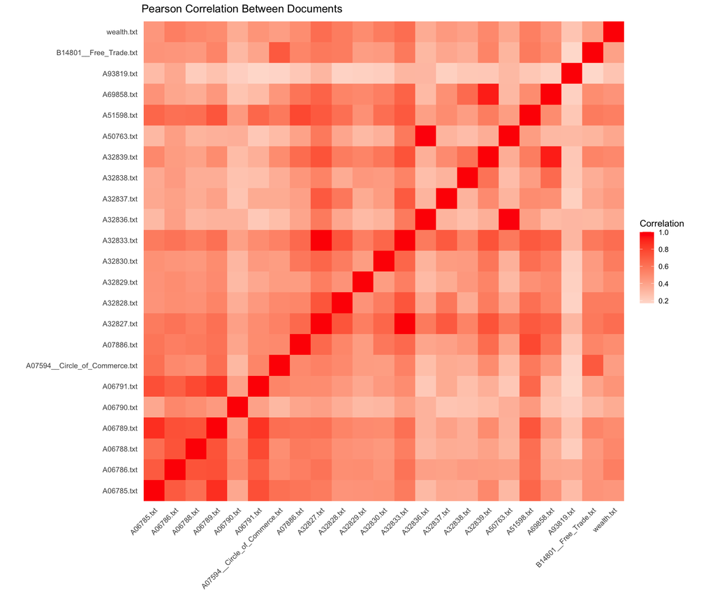

```r
heat_df <- as.data.frame(round(r_mat, 3)) %>%
  rownames_to_column("doc_i") %>%
  pivot_longer(
    -doc_i,
    names_to = "doc_j",
    values_to = "r"
  )

ggplot(heat_df, aes(x = doc_j, y = doc_i, fill = r)) +
  geom_tile() +
  coord_fixed() +
  scale_fill_gradient2(
    low = "blue",
    mid = "white",
    high = "red",
    midpoint = 0
  ) +
  labs(
    title = "Pearson Correlation Between Documents",
    x = NULL,
    y = NULL,
    fill = "Correlation"
  ) +
  theme_minimal() +
  theme(
    axis.text.x = element_text(angle = 45, hjust = 1),
    panel.grid = element_blank()
  )
```

```r
pair_indices <- which(upper.tri(r_mat), arr.ind = TRUE)

pairs <- tibble(
  document_1 = rownames(r_mat)[pair_indices[, 1]],
  document_2 = colnames(r_mat)[pair_indices[, 2]],
  correlation = r_mat[pair_indices]
)

most_similar <- pairs %>%
  arrange(desc(correlation)) %>%
  slice_head(n = 2)

least_similar <- pairs %>%
  arrange(correlation) %>%
  slice_head(n = 2)

knitr::kable(
  most_similar %>%
    mutate(correlation = sprintf("%.17g", correlation)),
  caption = "Two Most Similar Document Pairs"
)
```

Two Most Similar Document Pairs

| document_1 | document_2 | correlation |
| --- | --- | --- |
| A32827.txt | A32833.txt | 0.99961345224579001 |
| A32836.txt | A50763.txt | 0.97966958795045 |

```r
knitr::kable(
  least_similar %>%
    mutate(correlation = sprintf("%.17g", correlation)),
  caption = "Two Least Similar Document Pairs"
)
```

Two Least Similar Document Pairs

| document_1 | document_2 | correlation |
| --- | --- | --- |
| A93819.txt | B14801__Free_Trade.txt | 0.17000288297258001 |
| A06791.txt | A93819.txt | 0.17486131327491999 |

## Interpretations

The most similar pair of documents are documents A32827 and A32833 which have a nearly perfect correlation score of 0.9996. The second most similar pair of documents are A32836 and A50763 with a correlation score of 0.97967.

The least similar pair of documents are A93819 and B14801__Free_Trade with a correlation score of 0.17. The second least similar pair of documents are A06791 and A93819 with a correlation score of 0.175.

According to the heatmap, the documents among the corpus seems to be fairly, soemtimes strongly, similar to one another. There are no negatively correlated documents in the entire corpus, with some even having near perfect correlation to one another. For this reason some interesting questions I would ask about the corpus would be:

1. Does the positive correlation across every pair of documents reflect a shared vocabulary of political economy, even when the texts discuss different subjects?
2. Is the entire corpus made up of documents written by only a few different authors?
3. Are all of these documents from the same time and place?

## Approach 3 - Syntactic complexity profile

Doucments selected: A06791 and A93819

```r
texts_df <- texts %>%
  filter(document %in% c("A06791.txt", "A93819.txt"))
```

```r
library(udpipe)

model_info <- udpipe_download_model(language = "english-ewt")
```

```
##  - This model has been trained on version 2.5 of data from https://universaldependencies.org
```

```
##  - The model is distributed under the CC-BY-SA-NC license: https://creativecommons.org/licenses/by-nc-sa/4.0
```

```
##  - Visit https://github.com/jwijffels/udpipe.models.ud.2.5 for model license details.
```

```
##  - For a list of all models and their licenses (most models you can download with this package have either a CC-BY-SA or a CC-BY-SA-NC license) read the documentation at ?udpipe_download_model. For building your own models: visit the documentation by typing vignette('udpipe-train', package = 'udp…
```

```r
ud_model <- udpipe_load_model(model_info$file_model)
```

```r
anno_df <- texts_df %>%
  mutate(
    anno = map2(
      text, document,
      ~ udpipe_annotate(ud_model, x = .x, doc_id = .y) %>%
        as.data.frame()
    )
  ) %>%
  select(anno) %>%
  unnest(anno) %>%
  rename(document = doc_id) %>%
  select(
    document,
    paragraph_id,
    sentence_id,
    token_id,
    token,
    lemma,
    upos,
    feats,
    head_token_id,
    dep_rel
  )
anno_df
```

```
## # A tibble: 24,098 × 10
##    document   paragraph_id sentence_id token_id token       lemma    upos  feats
##    <chr>             <int>       <int> <chr>    <chr>       <chr>    <chr> <chr>
##  1 A06791.txt            1           1 1        PLato       PLato    ADP   <NA>
##  2 A06791.txt            1           1 2        the         the      DET   Defi…
##  3 A06791.txt            1           1 3        Philosopher Philoso… PROPN Numb…
##  4 A06791.txt            1           1 4        perceiving  perceive VERB  Verb…
##  5 A06791.txt            1           1 5        that        that     DET   Numb…
##  6 A06791.txt            1           1 6        equality    equality NOUN  Numb…
##  7 A06791.txt            1           1 7        would       would    AUX   Verb…
##  8 A06791.txt            1           1 8        be          be       AUX   Verb…
##  9 A06791.txt            1           1 9        the         the      DET   Defi…
## 10 A06791.txt            1           1 10       cause       cause    NOUN  Numb…
## # ℹ 24,088 more rows
## # ℹ 2 more variables: head_token_id <chr>, dep_rel <chr>
```

```r
syntax_df <- anno_df %>%
  mutate(
    is_word = upos != "PUNCT",

    is_clause = (upos %in% c("VERB", "AUX")) &
      str_detect(coalesce(feats, ""), "VerbForm=Fin"),

    is_dep_clause = dep_rel %in% c(
      "advcl", "ccomp", "xcomp", "acl", "acl:relcl"
    ),

    is_coord = dep_rel %in% c("conj", "cc"),

    is_complex_nominal = dep_rel %in% c(
      "amod", "nmod", "compound", "appos"
    )
  )
syntax_df
```

```
## # A tibble: 24,098 × 15
##    document   paragraph_id sentence_id token_id token       lemma    upos  feats
##    <chr>             <int>       <int> <chr>    <chr>       <chr>    <chr> <chr>
##  1 A06791.txt            1           1 1        PLato       PLato    ADP   <NA>
##  2 A06791.txt            1           1 2        the         the      DET   Defi…
##  3 A06791.txt            1           1 3        Philosopher Philoso… PROPN Numb…
##  4 A06791.txt            1           1 4        perceiving  perceive VERB  Verb…
##  5 A06791.txt            1           1 5        that        that     DET   Numb…
##  6 A06791.txt            1           1 6        equality    equality NOUN  Numb…
##  7 A06791.txt            1           1 7        would       would    AUX   Verb…
##  8 A06791.txt            1           1 8        be          be       AUX   Verb…
##  9 A06791.txt            1           1 9        the         the      DET   Defi…
## 10 A06791.txt            1           1 10       cause       cause    NOUN  Numb…
## # ℹ 24,088 more rows
## # ℹ 7 more variables: head_token_id <chr>, dep_rel <chr>, is_word <lgl>,
## #   is_clause <lgl>, is_dep_clause <lgl>, is_coord <lgl>,
## #   is_complex_nominal <lgl>
```

```r
sentence_df <- syntax_df %>%
  filter(is_word) %>%
  group_by(document, sentence_id) %>%
  summarise(
    words = n(),
    clauses = sum(is_clause),
    dep_clauses = sum(is_dep_clause),
    coordination = sum(is_coord),
    complex_nominals = sum(is_complex_nominal),
    .groups = "drop"
  )
sentence_df
```

```
## # A tibble: 495 × 7
##    document  sentence_id words clauses dep_clauses coordination complex_nominals
##    <chr>           <int> <int>   <int>       <int>        <int>            <int>
##  1 A06791.t…           1    97       8          10            9               14
##  2 A06791.t…           2    48       4           3            7                3
##  3 A06791.t…           3    60       3           3           13               10
##  4 A06791.t…           4    27       3           2            7                3
##  5 A06791.t…           5    15       1           1            0                5
##  6 A06791.t…           6    16       2           1            2                2
##  7 A06791.t…           7    30       2           2            1                1
##  8 A06791.t…           8    41       3           4            3                7
##  9 A06791.t…           9    34       1           4            3                6
## 10 A06791.t…          10    35       2           3            2                4
## # ℹ 485 more rows
```

```r
all_measures <- sentence_df %>%
  group_by(document) %>%
  summarise(
    MLS = mean(words),
    C_per_S = sum(clauses) / n(),
    DC_per_C = sum(dep_clauses) / pmax(sum(clauses), 1),
    DC_per_S = sum(dep_clauses) / n(),
    Coord_per_C = sum(coordination) / pmax(sum(clauses), 1),
    Coord_per_S = sum(coordination) / n(),
    CN_per_C = sum(complex_nominals) / pmax(sum(clauses), 1),
    CN_per_S = sum(complex_nominals) / n(),
    .groups = "drop"
  )

all_measures %>%
  mutate(across(where(is.numeric), ~ sprintf("%.17g", .x))) %>%
  knitr::kable(caption = "Syntactic Complexity Measures")
```

Syntactic Complexity Measures

| document | MLS | C_per_S | DC_per_C | DC_per_S | Coord_per_C | Coord_per_S | CN_per_C | CN_per_S |
| --- | --- | --- | --- | --- | --- | --- | --- | --- |
| A06791.txt | 43.00919540229885 | 3.0206896551724136 | 0.9634703196347032 | 2.9103448275862069 | 1.7199391171993912 | 5.195402298850575 | 1.9223744292237444 | 5.8068965517241375 |
| A93819.txt | 43.616666666666667 | 2.6666666666666665 | 0.84375 | 2.25 | 2.3187500000000001 | 6.1833333333333336 | 2.8312499999999998 | 7.5499999999999998 |

```r
texts_df %>%
  mutate(sentences = stringr::str_split(text, "(?<=[.!?])\\s+")) %>%
  tidyr::unnest(sentences) %>%
  filter(
    (document == "A06791.txt" &
       stringr::str_detect(sentences, fixed("The like would happen"))) |
    (document == "A93819.txt" &
       stringr::str_detect(sentences, fixed("have Indicted the Defendant")))
  ) %>%
  select(document, sentences) %>%
  knitr::kable()
```

| document | sentences |
| --- | --- |
| A06791.txt | The like would happen if the money were embased by allay, as we have seen by the sequel of things yet fresh in memory, during the most victorious reign of king Henry the 8. |
| A93819.txt | THe said Persons in the Name of the City of London, (but for their own private advantage only) have Indicted the Defendant for stopping up the Stairs at Lion-Key aforesaid, and a passage formerly lead… |

## Syntactic Difference

A06791 more often builds sentences by adding conditions and explanations to a main statement. A93819 more often joins actions or items together and adds details describing people, places, and things. A06791 uses more dependent clauses, while A93819 uses more coordination and noun modifiers. In A06791, ‘if the money were embased by allay’ adds a condition to the main statement. In A93819, ‘for stopping,’ ‘for planking,’ and ‘for erecting’ join three actions into a list. These examples show the difference between adding dependent clauses and joining actions together.

## Interpretation

How do the two texts differ in syntactic complexity?

The sentences in both texts are about the same length, but they are strung together differently. A06791 uses more clauses to add conditions and explanations. A93819 joins more actions or items together and adds more details to nouns. The syntactic complexity of both documents is similar, but their depth of complexity is achieved in different ways.

Do these differences align with or complicate your earlier lexical findings?

These differences both align with and complicate the earlier lexical findings. These two texts were among the least similar in vocabulary across the corpus, and they also build their sentences differently. However, both use long, complex sentences, showing that they share some similarities in sentence structure despite their differences in vocabulary.

What kinds of rhetorical or stylistic practices might these syntactic patterns reflect?

A06791’s use of conditions and explanations may reflect an effort to persuade readers by laying out a logical argument about money and trade. A93819’s list of actions and detailed descriptions may reflect the writer’s need to clearly identify the accusations, people, and places involved, such as in a courtroom or trial. Both use long sentences, but for different purposes.

## Synthesis Question

Do differences in subject matter lead to differences in syntactic complexity?

## Discussion of Evidence

Based on our analysis on the distinctive words in A06791 and A93819, the two documents differed in vocabulary greatly. A06791 seemed more focused on trade and commerce having distinctive words such as “moneys”, “exchange”, “silver”, and “shillings”. While A93819 seems to be about a legal dispute having used words such as “defendant” and “indicted”. Among the entire corpus, every pair of documents had positive Pearson r correlation, however, the strength varied. A06791 and A93819 were among the least similar pairs. Their word patterns differed more than those of most other pairs, even though they still shared some vocabulary. Both documents had similar sentence length at about 43 words on average per sentence, however, A06791 had more dependent clauses per sentence, while A93819 had more coordination and noun modifiers. Both documents use complex sentences, but the nature in which sentences are built in each document differs. The analysis of these two documents suggests that differences in subject matter may relate to how sentences are built, without one document being consistently more syntactically complex than the other. Further investigation could examine whether texts about more serious subjects use more complex sentences.